# FigureYa158MutationPattern

**Author(s)**: Rongfang Shen  
**Reviewer(s)**: Ying Ge, Junyi Shen  
**Date**: `r Sys.Date()`

# Academic Citation

If you use this code in your work or research, we kindly request that you cite our publication:

Xiaofan Lu, et al. (2025). FigureYa: A Standardized Visualization Framework for Enhancing Biomedical Data Interpretation and Research Efficiency. iMetaMed. https://doi.org/10.1002/imm3.70005

# 需求描述

# Requirement Description

输入TCGA突变数据，用非负矩阵分解方法NMF分析突变特征，重复出如下图。 Input TCGA mutation data and analyze mutation signatures using the non-negative matrix factorization (NMF) method, producing the following image.

[figure not shown]

出自https://www.ncbi.nlm.nih.gov/pmc/articles/PMC4610178/ From https://www.ncbi.nlm.nih.gov/pmc/articles/PMC4610178/

# 应用场景

# Application Scenario

突变特征定义：体细胞突变是多个突变过程如DNA修复缺陷，暴露于外源或内源诱变剂等综合结果。不同的突变过程会产生不同组合的突变类型，即突变特征。利用突变特征分析感兴趣癌种突变特征，探讨其可能的发生病因及机制。 目前已经有很多的R包可以帮助我们完成mutation signature分析如MutationalPatterns,maftools,deconstructSigs ,SomaticSignatures. Mutation signature definition: Somatic mutations are the combined result of multiple mutational processes, such as DNA repair defects and exposure to exogenous or endogenous mutagens. Different mutational processes produce different combinations of mutation types, known as mutation signatures. Mutation signatures are used to analyze the mutational characteristics of cancers of interest and explore their potential causes and mechanisms. Currently, many R packages exist to assist with mutation signature analysis, such as MutationalPatterns, maftools, deconstructSigs, and SomaticSignatures.

在这里我们选用maftools + MutationalPatterns来完成分析。 Here, we use maftools + MutationalPatterns to perform this analysis.

# 环境设置

# Environment Setup

```r
source("install_dependencies.R")
```

[output not shown]

```r
library(MutationalPatterns)
library(TCGAbiolinks)
library(maftools)
library(magrittr)
```

```r
library(stringr)
library(NMF)
library(ggsci)
library(BSgenome)
library(ggplot2)
library(cowplot)
library(BSgenome.Hsapiens.UCSC.hg38)
Sys.setenv(LANGUAGE = "en") #显示英文报错信息
options(stringsAsFactors = FALSE) #禁止chr转成factor
```

# 输入文件的下载

# Download input files

用TCGAbiolinks下载突变信息、临床数据 Download mutation information and clinical data using TCGAbiolinks

```r
## 突变数据
## Mutation data
query <- GDCquery(
  project = "TCGA-BLCA",
  data.category = "Simple Nucleotide Variation",
  data.type = "Masked Somatic Mutation",
  workflow.type = "Aliquot Ensemble Somatic Variant Merging and Masking"
)
```

```
## o GDCquery: Searching in GDC database
```

```
## Genome of reference: hg38
```

```
## oo Accessing GDC. This might take a while...
```

```
## ooo Project: TCGA-BLCA
```

```
## oo Filtering results
```

```
## ooo By data.type
```

```
## ooo By workflow.type
```

```
## oo Checking data
```

```
## ooo Checking if there are duplicated cases
```

```
## ooo Checking if there are results for the query
```

```
## o Preparing output
```

```r
GDCdownload(query, method = "api", directory = "GDCdata")
```

```
## Of the 415 files for download 415 already exist.
```

```
## All samples have been already downloaded
```

```r
maf_BLCA <- GDCprepare(query, directory = "GDCdata")

#下载一次就好，保存到文件，便于后面加载
#Download once and save to a file for easy loading later
save(maf_BLCA, file = "maf_BLCA.RData")

## clinical data
blca_clinical <- TCGAquery_subtype(tumor = "blca")
```

```
## blca subtype information from:doi:10.1016/j.cell.2017.09.007
```

```r
#非肌层浸润性膀胱癌是指局限于膀胱黏膜层（Tis、Ta）及固有层（T1）
#Non-muscle invasive bladder cancer refers to cancer confined to the bladder mucosa (Tis, Ta) and lamina propria (T1)
table(blca_clinical$`AJCC Tumor category`)
```

```
##
##  ND  T1  T2  T3 T3b  T4 T4a  TX
##  32   1 123 193   3  58   1   1
```

```r
mibc_samples <- blca_clinical[blca_clinical$`AJCC Tumor category` %in%
                                c("T2", "T3", "T3b", "T4", "T4a"), ]$patient
```

# NMF分析 # NMF analysis

```r
# 载入前面下载的MIBC_mutation # Load the previously downloaded MIBC_mutation
load("maf_BLCA.RData")
maf_BLCA <- read.maf(maf_BLCA, isTCGA = T) %>% subsetMaf(., tsb = mibc_samples, isTCGA = TRUE)
```

```
## -Validating
## -Silent variants: 32015
## -Summarizing
## --Possible FLAGS among top ten genes:
##   TTN
##   MUC16
##   SYNE1
## -Processing clinical data
## --Missing clinical data
## -Finished in 4.303s elapsed (4.435s cpu)
## --Possible FLAGS among top ten genes:
##   TTN
##   MUC16
##   SYNE1
## -Processing clinical data
```

```r
#96 mutational profile：4*6*4=96
#这里useSyn选的不包含同义突变，要包含参数选T
#包含useSyn画出来的mutation signature跟原文更相似。
# Here, useSyn excludes synonymous mutations; select T to include them.
# Including useSyn yields a mutation signature that is more similar to the original text.
mut_mat <- trinucleotideMatrix(maf = maf_BLCA,
                               ref_genome = "BSgenome.Hsapiens.UCSC.hg38",
                               prefix = NULL, ignoreChr = NULL,
                               useSyn = FALSE) %>% .$nmf_matrix %>% t()
```

```
## -Extracting 5' and 3' adjacent bases
## -Extracting +/- 20bp around mutated bases for background C>T estimation
## -Estimating APOBEC enrichment scores
## --Performing one-way Fisher's test for APOBEC enrichment
## ---APOBEC related mutations are enriched in  81.233 % of samples (APOBEC enrichment score > 2 ;  303  of  373  samples)
## -Creating mutation matrix
## --matrix of dimension 373x96
```

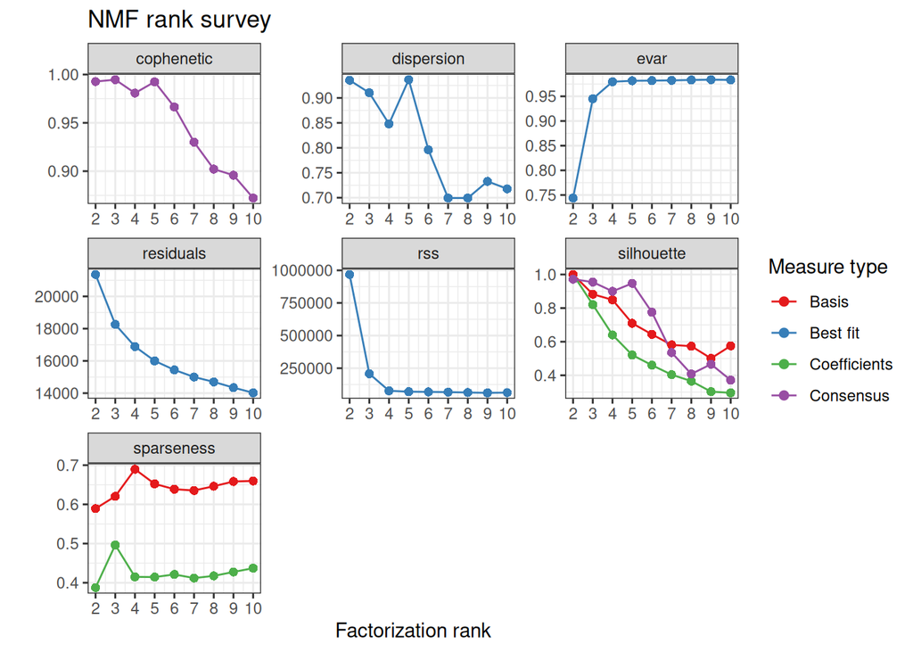

```r
#De novo mutational signature extraction using NMF
#用于自己的数据run最好在30-50之间，为了加快速度这里用10
#For your own data, the optimal number of runs is between 30 and 50. For speed, we use 10 here.
mut_mat <- mut_mat + 0.0001
estimate <- nmf(mut_mat, rank=2:10, method="brunet", nrun=10, seed=123456)#运行时间久 #Run time is long.
plot(estimate)
```

```r
#最佳个数的选择，一般选择cophenetic correlation开始下降的点，轮廓系数做大的点，详情请仔细阅读NMF说明文档。
#选择5作为最佳点,extract_signatures设置了seed:123456
#Choosing the optimal number of runs: generally, choose the point where the cophenetic correlation begins to decrease and the silhouette coefficient is large. Please read the NMF documentation carefully for details.
#Select 5 as the optimal point, set the seed value for extract_signatures to 123456
nmf_res <- extract_signatures(mut_mat, rank = 5, nrun = 30)
colnames(nmf_res$signatures) <- paste0("Signature", LETTERS[1:5])
rownames(nmf_res$contribution) <- paste0("Signature", LETTERS[1:5])
```